# 6.Expected-Values-for-Discreet-Random-Variables

```python
#renders matplotlib plots in the notebook
%matplotlib notebook

#enables tab autocomplete feature
%config IPCompleter.greedy=True

import numpy as np
import matplotlib.pyplot as plt
from scipy.stats import norm
```

## Expected Value of a Discreet Random Variable

$E(X) = \sum_{i}^{} x_i pX[x_i]$

$x_i$ values of the random variable X

$pX$ - PMF of the random variable X

### Interpretations

- It is the outcome of an experiment in the long run
- Average of the outcome of the experiment repeated many times
- Center of Mass of linearly arranged masses where $x_i$ is the position and its mass is given by $pX[x_i]$
- Expected value is the best predictor of the outcome of the experiment, where best means this value minimizes the Mean Square Error (MSE)

### Properties

- It does not indicate the most probable value of the random variable
- Different PMF can have smae expected value
- Not all PMFs have expected value, for some cases the the sum goes to infinity

## Expected Value for a function of Random Variable

Let $Y = g(X)$ is the mapping of random variable X

$E(Y) = \sum_{i}^{}y_i PY(y_i)$

$E(Y) = \sum_{i}^{}g(x_i) PY(g(x_i))$

$E(Y) = \sum_{i}^{}g(x_i) PX(x_i)$ since $PX = PY . g$

$E(g[X]) = \sum_{i}^{}g(x_i) PX(x_i)$

### Expectation Operator is linear

$E(a_1X_1 + a_2X2) = a_1E(X_1) + a_2E(X_2)$

## Variance and Moments of a Random Variable

$Var(X) = E[(X - E[X])^2]$

Variance measures the average squared deviation from the mean of a random variable

$Var(X) = E[g(X)]$ where $g(X) = (X-E[X])^2$

$Var(X) = \sum_{i}^{} (x_i-E[X])^2 PX(x_i)$ applying $E(g[X]) = \sum_{i}^{}g(x_i) PX(x_i)$

#### Alternate Expression for Variance

$Var(X) = E[(X - E[X])^2]$

$Var(X) = E[X^2 - 2XE[X] + E[X]^2]$ expanding

$Var(X) = E[X^2] - 2E[X]E[X] + E[X]^2$ applying linearity of E and E[constant] = constant

$Var(X) = E[X^2] - E[X]^2$

#### Properties

$var(c) = 0$

$var(X + c) = var(X)$ - shifting the values to left or right doesn't affect the variance

$var(cX) = c^2var(X)$ - expanding or squishing the values has an quadratic effect

Variance is a non-linear operator

Variance is the minimum value of MSE or the value of MSE at x = E(X), since E(X) minimizes MSE.

**Variance limits how well we can predict the outcome of an experiment. Expected value is the best prediction but variance qualifies how good the prediction is. This is assuming that we are minimizing MSE**

### First and Second Moments

$E(X)$ - First Moment

$E(X^2)$ - Second Moment

$E(X^n)$ - nth moment

#### Properties

- If nth moment is finite then 1 to n-1 moments are also finite
- Mean and Variance of a random variable will exist if second moment is finite

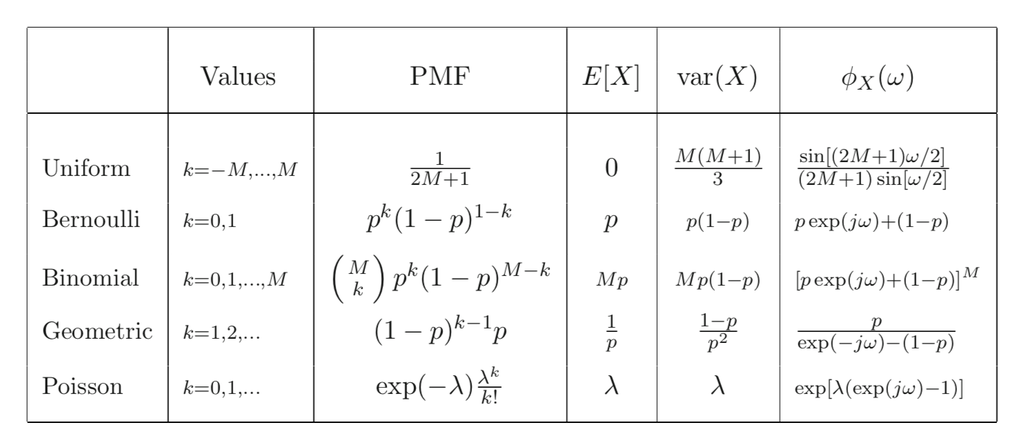

```python
import math
math.sqrt(9.8)
```

```
3.1304951684997055
```